# Classifying Wine Quality

#### Problem statement

Determine what constitutes a “good” quality wine based on the physicochemical predictors.

Knowing what makes a good wine was an interesting question because it allows us to look at “taste” in a different way–without formal training in wine tasting, we can determine algorithmically how and why a wine is good using machine learning.

Determine which of the 11 physicochemical predictors are most important, and build a classifier to predict the target “quality” attribute.

#### Data dictionary about the datasets

Physicochemical predictors:

1 - fixed acidity  
2 - volatile acidity  
3 - citric acid  
4 - residual sugar  
5 - chlorides  
6 - free sulfur dioxide  
7 - total sulfur dioxide  
8 - density  
9 - pH  
10 - sulphates  
11 - alcohol

Output variable (based on sensory data):  
12 - quality (score between 0 and 10)

#### Install the necessary libraries

```r
options(warn=-1)
library(caret)
library(dplyr)
library(skimr)
library(RANN)
library(e1071)
library(PerformanceAnalytics)
library(outliers)
```

#### Load the data

```r
dataset.red.wines <- read.csv('winequality-red.csv', sep = ";")
```

#### Explore the data

```r
str(dataset.red.wines)
```

```
## 'data.frame':    1599 obs. of  12 variables:
##  $ fixed.acidity       : num  7.4 7.8 7.8 11.2 7.4 7.4 7.9 7.3 7.8 7.5 ...
##  $ volatile.acidity    : num  0.7 0.88 0.76 0.28 0.7 0.66 0.6 0.65 0.58 0.5 ...
##  $ citric.acid         : num  0 0 0.04 0.56 0 0 0.06 0 0.02 0.36 ...
##  $ residual.sugar      : num  1.9 2.6 2.3 1.9 1.9 1.8 1.6 1.2 2 6.1 ...
##  $ chlorides           : num  0.076 0.098 0.092 0.075 0.076 0.075 0.069 0.065 0.073 0.071 ...
##  $ free.sulfur.dioxide : num  11 25 15 17 11 13 15 15 9 17 ...
##  $ total.sulfur.dioxide: num  34 67 54 60 34 40 59 21 18 102 ...
##  $ density             : num  0.998 0.997 0.997 0.998 0.998 ...
##  $ pH                  : num  3.51 3.2 3.26 3.16 3.51 3.51 3.3 3.39 3.36 3.35 ...
##  $ sulphates           : num  0.56 0.68 0.65 0.58 0.56 0.56 0.46 0.47 0.57 0.8 ...
##  $ alcohol             : num  9.4 9.8 9.8 9.8 9.4 9.4 9.4 10 9.5 10.5 ...
##  $ quality             : int  5 5 5 6 5 5 5 7 7 5 ...
```

```r
head(dataset.red.wines)
```

|  | fixed.acidity | volatile.acidity | citric.acid | residual.sugar | chlorides | free.sulfur.dioxide | total.sulfur.dioxide | density | pH | sulphates | alcohol | quality |
| --- | --- | --- | --- | --- | --- | --- | --- | --- | --- | --- | --- | --- |
| 1 | 7.4 | 0.70 | 0.00 | 1.9 | 0.076 | 11 | 34 | 0.9978 | 3.51 | 0.56 | 9.4 | 5 |
| 2 | 7.8 | 0.88 | 0.00 | 2.6 | 0.098 | 25 | 67 | 0.9968 | 3.20 | 0.68 | 9.8 | 5 |
| 3 | 7.8 | 0.76 | 0.04 | 2.3 | 0.092 | 15 | 54 | 0.9970 | 3.26 | 0.65 | 9.8 | 5 |
| 4 | 11.2 | 0.28 | 0.56 | 1.9 | 0.075 | 17 | 60 | 0.9980 | 3.16 | 0.58 | 9.8 | 6 |
| 5 | 7.4 | 0.70 | 0.00 | 1.9 | 0.076 | 11 | 34 | 0.9978 | 3.51 | 0.56 | 9.4 | 5 |
| 6 | 7.4 | 0.66 | 0.00 | 1.8 | 0.075 | 13 | 40 | 0.9978 | 3.51 | 0.56 | 9.4 | 5 |

```r
skim_to_wide(dataset.red.wines)
```

| type | variable | missing | complete | n | mean | sd | p0 | p25 | p50 | p75 | p100 | hist |
| --- | --- | --- | --- | --- | --- | --- | --- | --- | --- | --- | --- | --- |
| integer | quality | 0 | 1599 | 1599 | 5.64 | 0.81 | 3 | 5 | 6 | 6 | 8 | ▁▁▁▇▇▁▂▁ |
| numeric | alcohol | 0 | 1599 | 1599 | 10.42 | 1.07 | 8.4 | 9.5 | 10.2 | 11.1 | 14.9 | ▂▇▅▃▂▁▁▁ |
| numeric | chlorides | 0 | 1599 | 1599 | 0.087 | 0.047 | 0.012 | 0.07 | 0.079 | 0.09 | 0.61 | ▇▃▁▁▁▁▁▁ |
| numeric | citric.acid | 0 | 1599 | 1599 | 0.27 | 0.19 | 0 | 0.09 | 0.26 | 0.42 | 1 | ▇▅▅▆▂▁▁▁ |
| numeric | density | 0 | 1599 | 1599 | 1 | 0.0019 | 0.99 | 1 | 1 | 1 | 1 | ▁▁▃▇▇▂▁▁ |
| numeric | fixed.acidity | 0 | 1599 | 1599 | 8.32 | 1.74 | 4.6 | 7.1 | 7.9 | 9.2 | 15.9 | ▁▇▇▅▂▁▁▁ |
| numeric | free.sulfur.dioxide | 0 | 1599 | 1599 | 15.87 | 10.46 | 1 | 7 | 14 | 21 | 72 | ▇▇▅▂▁▁▁▁ |
| numeric | pH | 0 | 1599 | 1599 | 3.31 | 0.15 | 2.74 | 3.21 | 3.31 | 3.4 | 4.01 | ▁▁▅▇▅▁▁▁ |
| numeric | residual.sugar | 0 | 1599 | 1599 | 2.54 | 1.41 | 0.9 | 1.9 | 2.2 | 2.6 | 15.5 | ▇▂▁▁▁▁▁▁ |
| numeric | sulphates | 0 | 1599 | 1599 | 0.66 | 0.17 | 0.33 | 0.55 | 0.62 | 0.73 | 2 | ▂▇▂▁▁▁▁▁ |

[output cut: 2 more lines]

```r
summary(dataset.red.wines)
```

```
##  fixed.acidity   volatile.acidity  citric.acid    residual.sugar
##  Min.   : 4.60   Min.   :0.1200   Min.   :0.000   Min.   : 0.900
##  1st Qu.: 7.10   1st Qu.:0.3900   1st Qu.:0.090   1st Qu.: 1.900
##  Median : 7.90   Median :0.5200   Median :0.260   Median : 2.200
##  Mean   : 8.32   Mean   :0.5278   Mean   :0.271   Mean   : 2.539
##  3rd Qu.: 9.20   3rd Qu.:0.6400   3rd Qu.:0.420   3rd Qu.: 2.600
##  Max.   :15.90   Max.   :1.5800   Max.   :1.000   Max.   :15.500
##    chlorides       free.sulfur.dioxide total.sulfur.dioxide
##  Min.   :0.01200   Min.   : 1.00       Min.   :  6.00
##  1st Qu.:0.07000   1st Qu.: 7.00       1st Qu.: 22.00
##  Median :0.07900   Median :14.00       Median : 38.00
##  Mean   :0.08747   Mean   :15.87       Mean   : 46.47
##  3rd Qu.:0.09000   3rd Qu.:21.00       3rd Qu.: 62.00
##  Max.   :0.61100   Max.   :72.00       Max.   :289.00
##     density             pH          sulphates         alcohol
##  Min.   :0.9901   Min.   :2.740   Min.   :0.3300   Min.   : 8.40
##  1st Qu.:0.9956   1st Qu.:3.210   1st Qu.:0.5500   1st Qu.: 9.50
##  Median :0.9968   Median :3.310   Median :0.6200   Median :10.20
##  Mean   :0.9967   Mean   :3.311   Mean   :0.6581   Mean   :10.42
##  3rd Qu.:0.9978   3rd Qu.:3.400   3rd Qu.:0.7300   3rd Qu.:11.10
##  Max.   :1.0037   Max.   :4.010   Max.   :2.0000   Max.   :14.90
##     quality
##  Min.   :3.000
##  1st Qu.:5.000
##  Median :6.000
##  Mean   :5.636
##  3rd Qu.:6.000
##  Max.   :8.000
```

#### Feature plotting

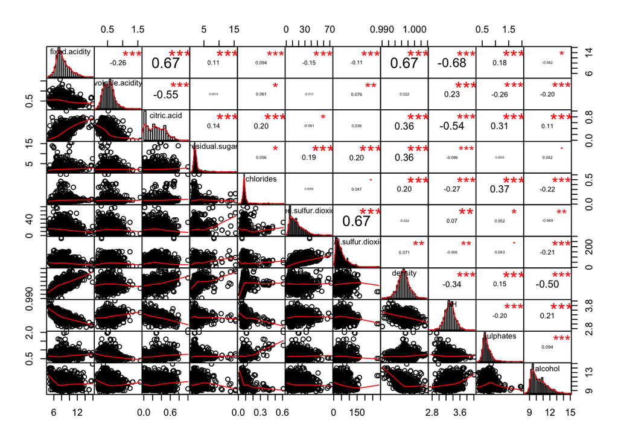

```r
x = dataset.red.wines[,1:11]
y = dataset.red.wines$quality

chart.Correlation(x, bg=y)
```

This chart contains a LOT of information: On the diagonal are the univariate distributions, plotted as histograms and kernel density plots. On the right of the diagonal are the pair-wise correlations, with red stars signifying significance levels. As the correlations get bigger the font size of the coefficient gets bigger. On the left side of the diagonal is the scatter-plot matrix, with loess smoothers in red to help illustrate the underlying relationship.

These distributions indicate a large issue with outliers.

Dig deeper into the outliers by using a boxplot visualization.

##### Outlier Analysis

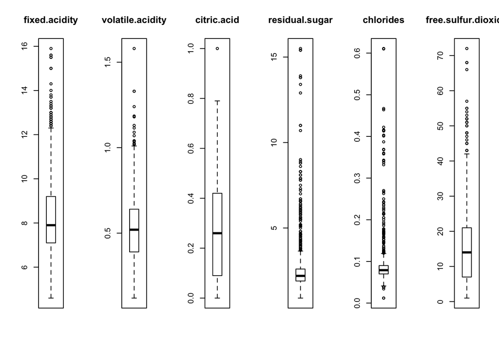

```r
# boxplots
par(mfrow=c(1,6))
  for(i in 1:6) {
  boxplot(x[,i], main=names(dataset.red.wines)[i])
  }
```

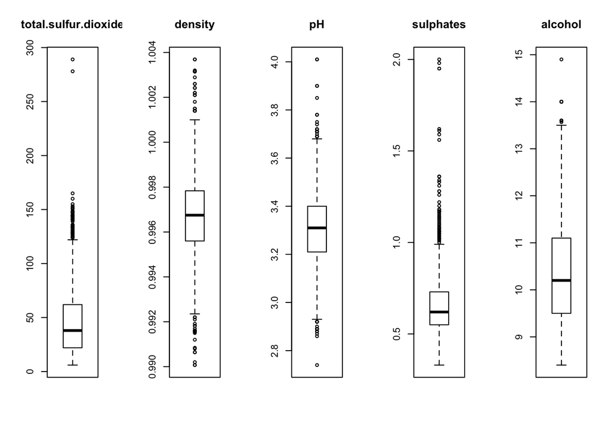

```r
par(mfrow=c(1,5))
for(i in 7:11) {
  boxplot(x[,i], main=names(dataset.red.wines)[i])
  }
```

Most of the variables have a high number of outliers. Modelling later will need to experiment with outlier treatment, such as imputation, capping, or omission.

##### Correlation between “quality” and other predictors

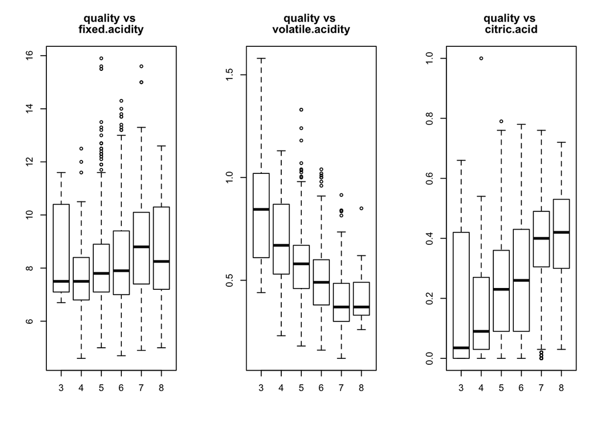

```r
par(mfrow=c(1,3))
  for(i in 1:3) {
  boxplot(x[,i] ~ y, main=c("quality vs ",names(dataset.red.wines)[i]))
  }
```

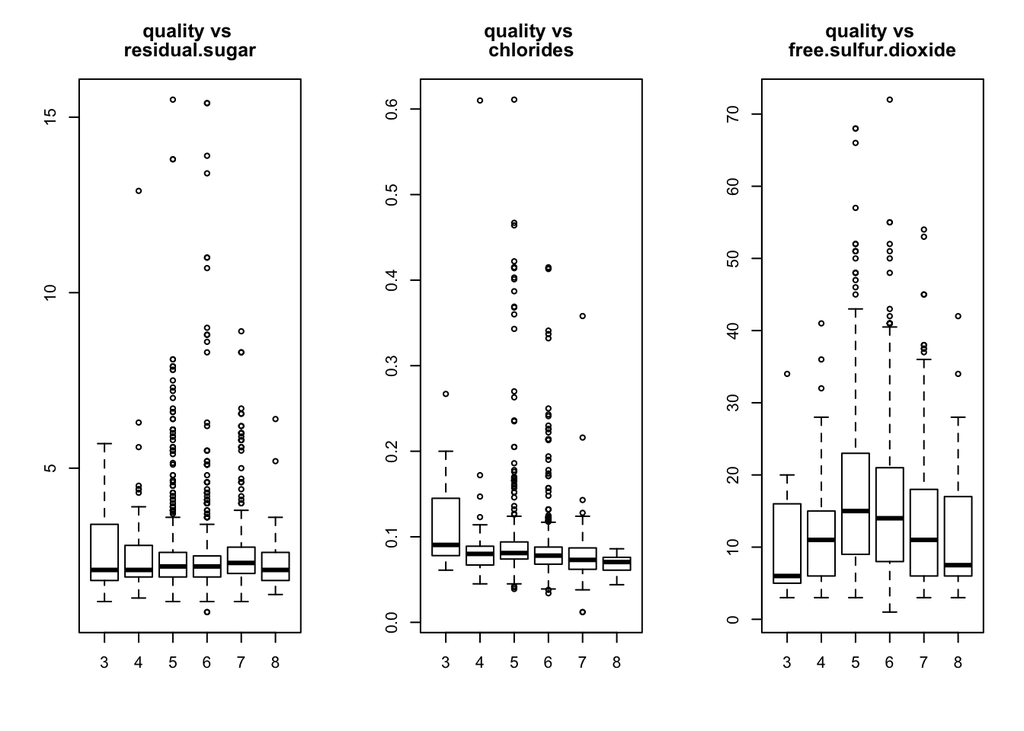

```r
par(mfrow=c(1,3))
  for(i in 4:6) {
  boxplot(x[,i] ~ y, main=c("quality vs ",names(dataset.red.wines)[i]))
  }
```

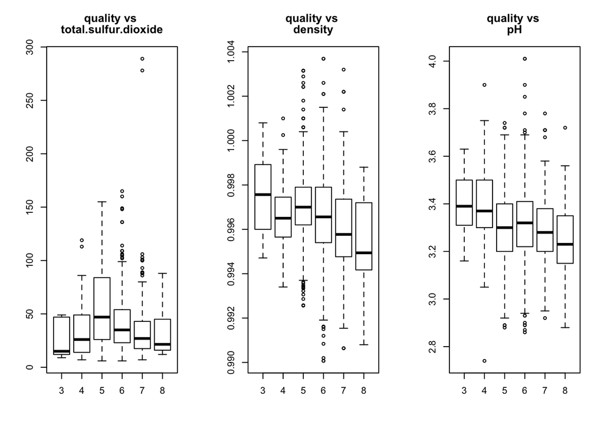

```r
par(mfrow=c(1,3))
  for(i in 7:9) {
  boxplot(x[,i] ~ y, main=c("quality vs ",names(dataset.red.wines)[i]))
  }
```

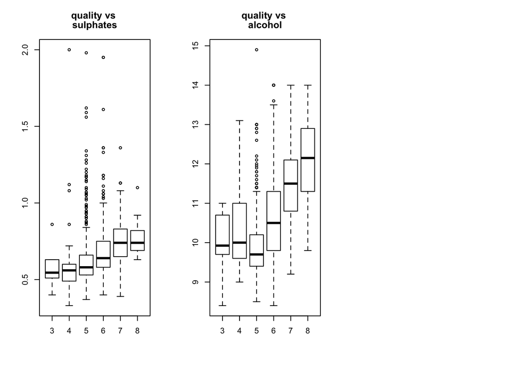

```r
par(mfrow=c(1,3))
  for(i in 10:11) {
  boxplot(x[,i] ~ y, main=c("quality vs ",names(dataset.red.wines)[i]))
  }
```

#### Observations about the data

##### Imputation

- No missing values

##### Outliers

- The plots show outliers - they are 1.5 times the IQR (interquartile range) more extreme than the quartiles of the distribution
- Every predictor has *some* outliers and only *citric.acid* has just a single outlier
- *Chlorides*, *pH*, and *density* have outliers above and below the distribution
- The predictors with outliers on the high side are artificially moving the mean off the visible center of the curve, and vice versa.

##### Correlation

- There is a negative correlation between the target *quality* and the predictors *volatile acidity*, *pH*, and *density*.
- There is a positive correlation between the target *quality* and the predictors *citric acid*, *sulphates*, and *alcohol*.

#### Create training and validation datasets

```r
# convert the quality attribute to a real 3-level factor
dataset.red.wines$quality[which(dataset.red.wines$quality == 3 | dataset.red.wines$quality == 4)] <- 'poor'
dataset.red.wines$quality[which(dataset.red.wines$quality == 5 | dataset.red.wines$quality == 6)] <- 'good'
dataset.red.wines$quality[which(dataset.red.wines$quality == 7 | dataset.red.wines$quality == 8)] <- 'great'
dataset.red.wines$quality <- as.factor(dataset.red.wines$quality)
```

```r
set.seed(100)

# Step 1: get row numbers for the training data
training.row.numbers <- createDataPartition(dataset.red.wines$quality, p=0.8, list=FALSE)

# Step 2: create the training  dataset
dataset.training <- dataset.red.wines[training.row.numbers,]

# Step 3: create the test dataset
dataset.testing <- dataset.red.wines[-training.row.numbers,]
```

```r
str(dataset.training)
```

```
## 'data.frame':    1281 obs. of  12 variables:
##  $ fixed.acidity       : num  7.4 7.8 7.8 11.2 7.4 7.3 7.8 7.5 6.7 7.5 ...
##  $ volatile.acidity    : num  0.7 0.88 0.76 0.28 0.66 0.65 0.58 0.5 0.58 0.5 ...
##  $ citric.acid         : num  0 0 0.04 0.56 0 0 0.02 0.36 0.08 0.36 ...
##  $ residual.sugar      : num  1.9 2.6 2.3 1.9 1.8 1.2 2 6.1 1.8 6.1 ...
##  $ chlorides           : num  0.076 0.098 0.092 0.075 0.075 0.065 0.073 0.071 0.097 0.071 ...
##  $ free.sulfur.dioxide : num  11 25 15 17 13 15 9 17 15 17 ...
##  $ total.sulfur.dioxide: num  34 67 54 60 40 21 18 102 65 102 ...
##  $ density             : num  0.998 0.997 0.997 0.998 0.998 ...
##  $ pH                  : num  3.51 3.2 3.26 3.16 3.51 3.39 3.36 3.35 3.28 3.35 ...
##  $ sulphates           : num  0.56 0.68 0.65 0.58 0.56 0.47 0.57 0.8 0.54 0.8 ...
##  $ alcohol             : num  9.4 9.8 9.8 9.8 9.4 10 9.5 10.5 9.2 10.5 ...
##  $ quality             : Factor w/ 3 levels "good","great",..: 1 1 1 1 1 2 2 1 1 1 ...
```

#### Try several models WITHOUT adjusting outliers

```r
# Define the training control - this problem has THREE classes so ROC is not available
fit.control <- trainControl(
    method = 'cv',                   # k-fold cross validation
    number = 5,                      # number of folds
    savePredictions = 'final',       # saves predictions for optimal tuning parameter
    classProbs = T#,                  # should class probabilities be returned
    #summaryFunction=twoClassSummary  # results summary function
)
```

```r
set.seed(100)

set.seed(100)

# train random forest
model.rf = train(quality ~ .,
                 data=dataset.training,
                 method='rf',
                 tuneLength=5,
                 trControl = fit.control)


# train SVM
model.svm = train(quality ~ .,
                  data=dataset.training,
                  method='svmRadial',
                  tuneLength=15,
                  trControl = fit.control)


# train k-nearest neighbors
model.knn = train(quality ~ .,
                  data=dataset.training,
                  method='knn',
                  tuneLength=5,
                  trControl=fit.control)


# train naive baise classifier
model.nb = train(quality ~ .,
                  data=dataset.training,
                  method='nb',
                  tuneLength=5,
                  trControl=fit.control)
```

```r
# Compare model performances using resample()
models.compared <- resamples(list(`Random Forest`=model.rf,
                                  `SVM`=model.svm,
                                  `kNN`=model.knn,
                                  `Naive Bayes`=model.nb
                                  ))

# Summary of the models performances
summary(models.compared)
```

```
##
## Call:
## summary.resamples(object = models.compared)
##
## Models: Random Forest, SVM, kNN, Naive Bayes
## Number of resamples: 5
##
## Accuracy
##                    Min.   1st Qu.    Median      Mean   3rd Qu.      Max.
## Random Forest 0.8482490 0.8750000 0.8754864 0.8712146 0.8784314 0.8789062
## SVM           0.8410853 0.8431373 0.8632812 0.8563758 0.8632812 0.8710938
## kNN           0.8242188 0.8249027 0.8320312 0.8306106 0.8326848 0.8392157
## Naive Bayes   0.7812500 0.8007812 0.8100775 0.8087465 0.8156863 0.8359375
##               NA's
## Random Forest    0
## SVM              0
## kNN              0
## Naive Bayes      0
##
## Kappa
##                     Min.   1st Qu.    Median      Mean   3rd Qu.      Max.
## Random Forest 0.32052064 0.4444444 0.4616193 0.4500172 0.4937831 0.5297185
## SVM           0.19295033 0.2855642 0.3750000 0.3557713 0.4178794 0.5074627
## kNN           0.06356275 0.1401344 0.1454640 0.1405436 0.1608476 0.1927095
## Naive Bayes   0.33789026 0.3729709 0.3933199 0.4016532 0.4504472 0.4536379
##               NA's
## Random Forest    0
## SVM              0
## kNN              0
## Naive Bayes      0
```

Without any special data treatment, we see that random forest provides a model with *87.1%* accuracy, the best of the algorithms chosen. This is the baseline model, further attempts for improvement follow.

Baseline: Random Forest yields 87.1% accuracy, with no treatment for outliers and no feature engineering.

Next step: try dealing with outliers.

#### Try to improve accuracy using caret’s preProcess() function

```r
set.seed(100)

# train random forest
model.rf = train(quality ~ .,
                 data=dataset.training,
                 method='rf',
                 tuneLength=5,
                 preProcess = c("center", "scale"),
                 trControl = fit.control)
```

```r
set.seed(100)

# train random forest
model.rf = train(quality ~ .,
                 data=dataset.training,
                 method='rf',
                 tuneLength=5,
                 preProcess = c("center", "scale"),
                 trControl = fit.control)


# train SVM
model.svm = train(quality ~ .,
                  data=dataset.training,
                  method='svmRadial',
                  tuneLength=15,
                  preProcess = c("center", "scale"),
                  trControl = fit.control)


# train k-nearest neighbors
model.knn = train(quality ~ .,
                  data=dataset.training,
                  method='knn',
                  tuneLength=5,
                  preProcess = c("center", "scale"),
                  trControl=fit.control)

# train naive baise classifier
model.nb = train(quality ~ .,
                  data=dataset.training,
                  method='nb',
                  tuneLength=5,
                  preProcess = c("center", "scale"),
                  trControl=fit.control)
```

```r
# Compare model performances using resample()
models.compared <- resamples(list(`Random Forest`=model.rf,
                                  `SVM`=model.svm,
                                  `kNN`=model.knn,
                                  `Naive Bayes`=model.nb
                                  ))

# Summary of the models performances
summary(models.compared)
```

```
##
## Call:
## summary.resamples(object = models.compared)
##
## Models: Random Forest, SVM, kNN, Naive Bayes
## Number of resamples: 5
##
## Accuracy
##                    Min.   1st Qu.    Median      Mean   3rd Qu.      Max.
## Random Forest 0.8560311 0.8666667 0.8750000 0.8704150 0.8750000 0.8793774
## SVM           0.8404669 0.8437500 0.8443580 0.8493516 0.8549020 0.8632812
## kNN           0.8125000 0.8249027 0.8320312 0.8274805 0.8320312 0.8359375
## Naive Bayes   0.7960784 0.8054475 0.8085938 0.8079541 0.8093385 0.8203125
##               NA's
## Random Forest    0
## SVM              0
## kNN              0
## Naive Bayes      0
##
## Kappa
##                    Min.   1st Qu.    Median      Mean   3rd Qu.      Max.
## Random Forest 0.3868721 0.4394880 0.4870382 0.4758902 0.5299518 0.5361011
## SVM           0.2714009 0.3110872 0.3284118 0.3262291 0.3530138 0.3672316
## kNN           0.2824792 0.3069374 0.3440591 0.3320360 0.3582090 0.3684952
## Naive Bayes   0.3328834 0.3622854 0.3990034 0.3941980 0.4257900 0.4510279
##               NA's
## Random Forest    0
## SVM              0
## kNN              0
## Naive Bayes      0
```

Using preProcess() did not aid the accuracy at all.

#### Resolve outliers through capping

Try replacing the outliers with capped value, and re-run the algorithms.

For missing values that lie outside the 1.5 x IQR limits, we could cap it by replacing those observations outside the lower limit with the value of 5th %ile and those that lie above the upper limit, with the value of 95th %ile.

```r
dataset.training.original <- dataset.training

# apply capping to dataset.training$fixed.acidity
qnt <- quantile(dataset.training$fixed.acidity, probs=c(.25, .75), na.rm = T)
caps <- quantile(dataset.training$fixed.acidity, probs=c(.05, .95), na.rm = T)
H <- 1.5 * IQR(dataset.training$fixed.acidity, na.rm = T)
dataset.training$fixed.acidity[dataset.training$fixed.acidity < (qnt[1] - H)] <- caps[1]
dataset.training$fixed.acidity[dataset.training$fixed.acidity > (qnt[2] + H)] <- caps[2]

# apply capping to dataset.training$volatile.acidity
qnt <- quantile(dataset.training$volatile.acidity, probs=c(.25, .75), na.rm = T)
caps <- quantile(dataset.training$volatile.acidity, probs=c(.05, .95), na.rm = T)
H <- 1.5 * IQR(dataset.training$volatile.acidity, na.rm = T)
dataset.training$volatile.acidity[dataset.training$volatile.acidity < (qnt[1] - H)] <- caps[1]
dataset.training$volatile.acidity[dataset.training$volatile.acidity > (qnt[2] + H)] <- caps[2]

# apply capping to dataset.training$citric.acid
qnt <- quantile(dataset.training$citric.acid, probs=c(.25, .75), na.rm = T)
caps <- quantile(dataset.training$citric.acid, probs=c(.05, .95), na.rm = T)
H <- 1.5 * IQR(dataset.training$citric.acid, na.rm = T)
dataset.training$citric.acid[dataset.training$citric.acid < (qnt[1] - H)] <- caps[1]
dataset.training$citric.acid[dataset.training$citric.acid > (qnt[2] + H)] <- caps[2]

# apply capping to dataset.training$chlorides
qnt <- quantile(dataset.training$chlorides, probs=c(.25, .75), na.rm = T)
caps <- quantile(dataset.training$chlorides, probs=c(.05, .95), na.rm = T)
H <- 1.5 * IQR(dataset.training$chlorides, na.rm = T)
dataset.training$chlorides[dataset.training$chlorides < (qnt[1] - H)] <- caps[1]
dataset.training$chlorides[dataset.training$chlorides > (qnt[2] + H)] <- caps[2]

# apply capping to dataset.training$free.sulfur.dioxide
qnt <- quantile(dataset.training$free.sulfur.dioxide, probs=c(.25, .75), na.rm = T)
caps <- quantile(dataset.training$free.sulfur.dioxide, probs=c(.05, .95), na.rm = T)
H <- 1.5 * IQR(dataset.training$free.sulfur.dioxide, na.rm = T)
dataset.training$free.sulfur.dioxide[dataset.training$free.sulfur.dioxide < (qnt[1] - H)] <- caps[1]
dataset.training$free.sulfur.dioxide[dataset.training$free.sulfur.dioxide > (qnt[2] + H)] <- caps[2]

# apply capping to dataset.training$total.sulfur.dioxide
qnt <- quantile(dataset.training$total.sulfur.dioxide, probs=c(.25, .75), na.rm = T)
caps <- quantile(dataset.training$total.sulfur.dioxide, probs=c(.05, .95), na.rm = T)
H <- 1.5 * IQR(dataset.training$total.sulfur.dioxide, na.rm = T)
dataset.training$total.sulfur.dioxide[dataset.training$total.sulfur.dioxide < (qnt[1] - H)] <- caps[1]
dataset.training$total.sulfur.dioxide[dataset.training$total.sulfur.dioxide > (qnt[2] + H)] <- caps[2]

# apply capping to dataset.training$density
qnt <- quantile(dataset.training$density, probs=c(.25, .75), na.rm = T)
caps <- quantile(dataset.training$density, probs=c(.05, .95), na.rm = T)
H <- 1.5 * IQR(dataset.training$density, na.rm = T)
dataset.training$density[dataset.training$density < (qnt[1] - H)] <- caps[1]
dataset.training$density[dataset.training$density > (qnt[2] + H)] <- caps[2]

# apply capping to dataset.training$pH
qnt <- quantile(dataset.training$pH, probs=c(.25, .75), na.rm = T)
caps <- quantile(dataset.training$pH, probs=c(.05, .95), na.rm = T)
H <- 1.5 * IQR(dataset.training$pH, na.rm = T)
dataset.training$pH[dataset.training$pH < (qnt[1] - H)] <- caps[1]
dataset.training$pH[dataset.training$pH > (qnt[2] + H)] <- caps[2]

# apply capping to dataset.training$sulphates
qnt <- quantile(dataset.training$sulphates, probs=c(.25, .75), na.rm = T)
caps <- quantile(dataset.training$sulphates, probs=c(.05, .95), na.rm = T)
H <- 1.5 * IQR(dataset.training$sulphates, na.rm = T)
dataset.training$sulphates[dataset.training$sulphates < (qnt[1] - H)] <- caps[1]
dataset.training$sulphates[dataset.training$sulphates > (qnt[2] + H)] <- caps[2]

# apply capping to dataset.training$alcohol
qnt <- quantile(dataset.training$alcohol, probs=c(.25, .75), na.rm = T)
caps <- quantile(dataset.training$alcohol, probs=c(.05, .95), na.rm = T)
H <- 1.5 * IQR(dataset.training$alcohol, na.rm = T)
dataset.training$alcohol[dataset.training$alcohol < (qnt[1] - H)] <- caps[1]
dataset.training$alcohol[dataset.training$alcohol > (qnt[2] + H)] <- caps[2]

# apply capping to dataset.training$residual.sugar
qnt <- quantile(dataset.training$residual.sugar, probs=c(.25, .75), na.rm = T)
caps <- quantile(dataset.training$residual.sugar, probs=c(.05, .95), na.rm = T)
H <- 1.5 * IQR(dataset.training$residual.sugar, na.rm = T)
dataset.training$residual.sugar[dataset.training$residual.sugar < (qnt[1] - H)] <- caps[1]
dataset.training$residual.sugar[dataset.training$residual.sugar > (qnt[2] + H)] <- caps[2]
```

Observe that the number and severity of outliers has been resolved:

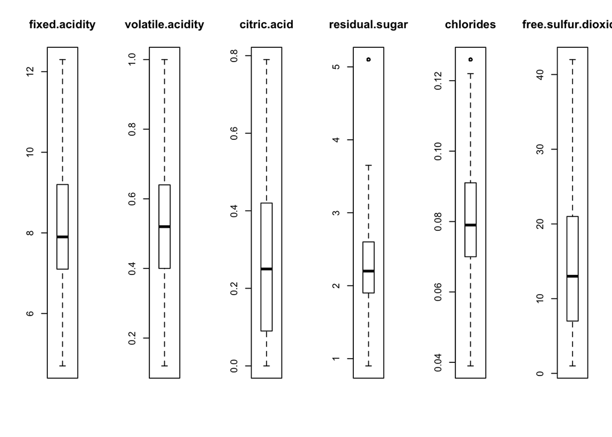

```r
# boxplots
par(mfrow=c(1,6))
  for(i in 1:6) {
  boxplot(dataset.training[,i], main=names(dataset.training)[i])
  }
```

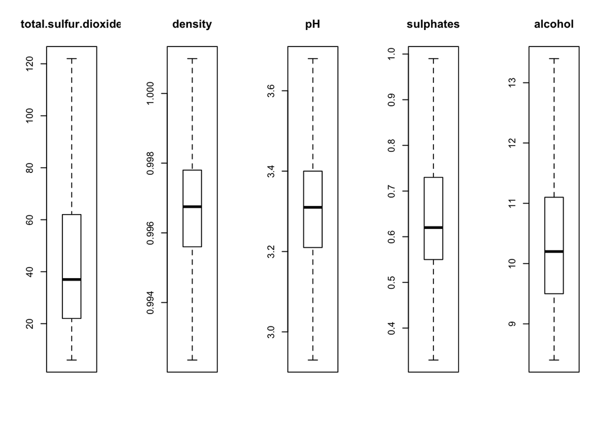

```r
# boxplots
par(mfrow=c(1,5))
  for(i in 7:11) {
  boxplot(dataset.training[,i], main=names(dataset.training)[i])
  }
```

```r
# re-build the models with the capped predictors
set.seed(100)

# train random forest
model.rf = train(quality ~ .,
                 data=dataset.training,
                 method='rf',
                 tuneLength=5,
                 trControl = fit.control)


# train SVM
model.svm = train(quality ~ .,
                  data=dataset.training,
                  method='svmRadial',
                  tuneLength=15,
                  trControl = fit.control)


# train k-nearest neighbors
model.knn = train(quality ~ .,
                  data=dataset.training,
                  method='knn',
                  tuneLength=5,
                  trControl=fit.control)


# train naive baise classifier
model.nb = train(quality ~ .,
                  data=dataset.training,
                  method='nb',
                  tuneLength=5,
                  trControl=fit.control)
```

```r
# Compare model performances using resample()
models.compared <- resamples(list(`Random Forest`=model.rf,
                                  `SVM`=model.svm,
                                  `kNN`=model.knn,
                                  `Naive Bayes`=model.nb
                                  ))

# Summary of the models performances
summary(models.compared)
```

```
##
## Call:
## summary.resamples(object = models.compared)
##
## Models: Random Forest, SVM, kNN, Naive Bayes
## Number of resamples: 5
##
## Accuracy
##                    Min.   1st Qu.    Median      Mean   3rd Qu.      Max.
## Random Forest 0.8627451 0.8638132 0.8710938 0.8688495 0.8715953 0.8750000
## SVM           0.8320312 0.8437500 0.8470588 0.8454171 0.8476562 0.8565891
## kNN           0.8125000 0.8196078 0.8210117 0.8259017 0.8320312 0.8443580
## Naive Bayes   0.7898833 0.8000000 0.8203125 0.8165509 0.8249027 0.8476562
##               NA's
## Random Forest    0
## SVM              0
## kNN              0
## Naive Bayes      0
##
## Kappa
##                     Min.    1st Qu.     Median      Mean    3rd Qu.
## Random Forest 0.40249046 0.40450182 0.46341463 0.4525323 0.48355864
## SVM           0.19248826 0.27398160 0.29437707 0.2881599 0.33617021
## kNN           0.05044177 0.06032204 0.07277628 0.1007041 0.08680143
## Naive Bayes   0.33685177 0.34292884 0.43700711 0.4090066 0.43985159
##                    Max. NA's
## Random Forest 0.5086962    0
## SVM           0.3437822    0
## kNN           0.2331792    0
## Naive Bayes   0.4883935    0
```

### Use RFE to determine the most important features

```r
# return the training dataset to the original state
dataset.training <- dataset.training.original

set.seed(100)

ctrl <- rfeControl(functions = rfFuncs,
                   method = "repeatedcv",
                   repeats = 5,
                   verbose = FALSE)

lmProfile <- rfe(x=dataset.red.wines[, 1:11], y=dataset.red.wines$quality, rfeControl=ctrl)

lmProfile
```

```
##
## Recursive feature selection
##
## Outer resampling method: Cross-Validated (10 fold, repeated 5 times)
##
## Resampling performance over subset size:
##
##  Variables Accuracy  Kappa AccuracySD KappaSD Selected
##          4   0.8682 0.4814    0.01821 0.07068
##          8   0.8753 0.4815    0.01715 0.08402        *
##         11   0.8744 0.4788    0.01948 0.09123
##
## The top 5 variables (out of 8):
##    alcohol, volatile.acidity, sulphates, total.sulfur.dioxide, residual.sugar
```

The top 5 variables (out of 8): alcohol, volatile.acidity, sulphates, total.sulfur.dioxide, residual.sugar

Indexes are (11,2,10,7,4)

```r
set.seed(100)

# train random forest
model.rf = train(quality ~ .,
                 data=dataset.training[c(11,2,10,7,4,12)],
                 method='rf',
                 tuneLength=5,
                 trControl = fit.control)
# train SVM
model.svm = train(quality ~ .,
                  data=dataset.training[c(11,2,10,7,4,12)],
                  method='svmRadial',
                  tuneLength=15,
                  trControl = fit.control)


# train k-nearest neighbors
model.knn = train(quality ~ .,
                  data=dataset.training[c(11,2,10,7,4,12)],
                  method='knn',
                  tuneLength=5,
                  trControl=fit.control)


# train naive baise classifier
model.nb = train(quality ~ .,
                  data=dataset.training[c(11,2,10,7,4,12)],
                  method='nb',
                  tuneLength=5,
                  trControl=fit.control)
```

```r
# Compare model performances using resample()
models.compared <- resamples(list(`Random Forest`=model.rf,
                                  `SVM`=model.svm,
                                  `kNN`=model.knn,
                                  `Naive Bayes`=model.nb
                                  ))

# Summary of the models performances
summary(models.compared)
```

```
##
## Call:
## summary.resamples(object = models.compared)
##
## Models: Random Forest, SVM, kNN, Naive Bayes
## Number of resamples: 5
##
## Accuracy
##                    Min.   1st Qu.    Median      Mean   3rd Qu.      Max.
## Random Forest 0.8437500 0.8627451 0.8750000 0.8664936 0.8754864 0.8754864
## SVM           0.8352941 0.8476562 0.8482490 0.8462022 0.8482490 0.8515625
## kNN           0.8085938 0.8156863 0.8287938 0.8258987 0.8365759 0.8398438
## Naive Bayes   0.8093385 0.8164062 0.8365759 0.8329696 0.8470588 0.8554688
##               NA's
## Random Forest    0
## SVM              0
## kNN              0
## Naive Bayes      0
##
## Kappa
##                     Min.   1st Qu.    Median      Mean   3rd Qu.      Max.
## Random Forest 0.40032795 0.4421526 0.4748739 0.4671843 0.4981007 0.5204665
## SVM           0.26025694 0.3038133 0.3214286 0.3177262 0.3234103 0.3797217
## kNN           0.06777646 0.1136011 0.1168385 0.1292254 0.1382724 0.2096386
## Naive Bayes   0.34622573 0.3737574 0.3816453 0.3911574 0.3945205 0.4596383
##               NA's
## Random Forest    0
## SVM              0
## kNN              0
## Naive Bayes      0
```

Using the features recommended from RFE did not increase the accuracy.

##### Use Principal Component Analysis to reduce the number of predictors in the model

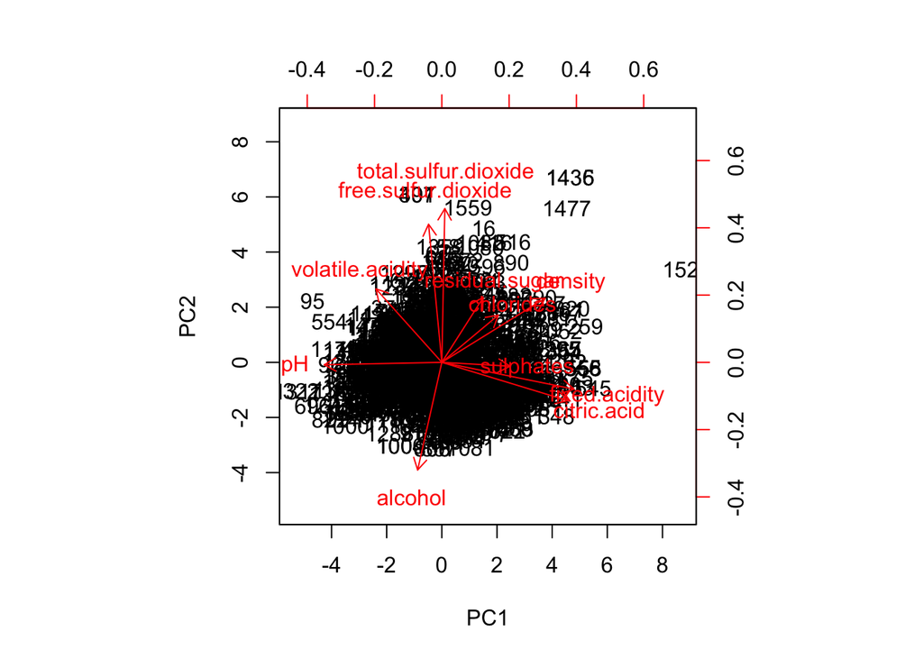

```r
pca <- prcomp(dataset.training[1:11], scale. = T)
biplot(pca, scale = 0)
```

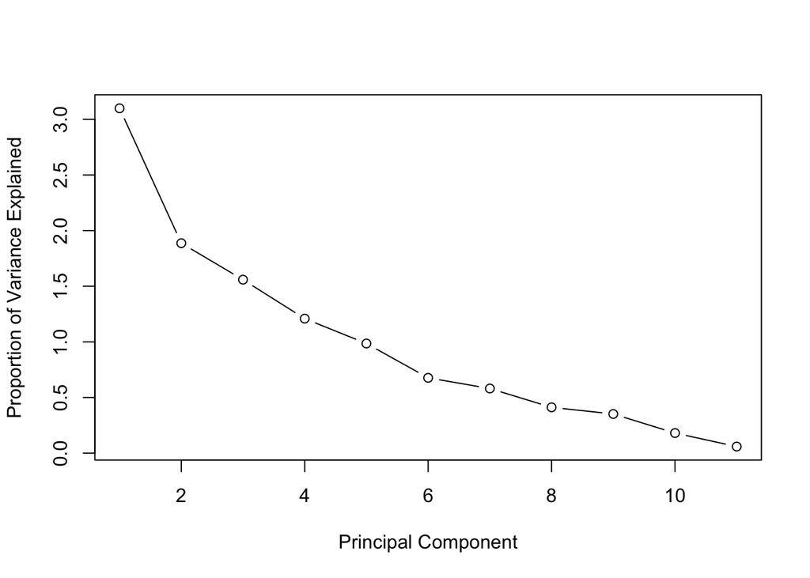

```r
# determine the proportion of variance explained by each variable
variance.proportion <- pca$sdev^2

# use scree plot to determine how many variables to use in modeling
plot(variance.proportion, xlab = "Principal Component",
             ylab = "Proportion of Variance Explained",
             type = "b")
```

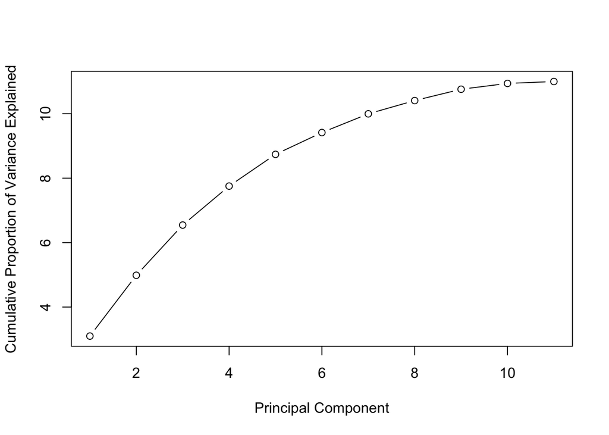

```r
#cumulative scree plot
plot(cumsum(variance.proportion), xlab = "Principal Component",
              ylab = "Cumulative Proportion of Variance Explained",
              type = "b")
```

Analysis shows the top 8-10 predictors explain most of the variance in the dataset.

Re-modeling with those variables may improve the accuracy.

```r
# build the training dataset from PCA
dataset.training.pca <- data.frame(quality = dataset.training$quality, pca$x)
dataset.training.pca <- dataset.training.pca[,1:10]
dataset.training.pca
```

|  | quality | PC1 | PC2 | PC3 | PC4 | PC5 | PC6 | PC7 | PC8 | PC9 |
| --- | --- | --- | --- | --- | --- | --- | --- | --- | --- | --- |
| 1 | good | -1.650040e+00 | 0.424551452 | 1.7758558663 | -0.0146672159 | 0.008398562 | -8.657286e-01 | -0.141994959 | 0.2237464419 | 0.0372366976 |
| 2 | good | -8.469453e-01 | 1.868000606 | 0.8650218787 | 0.4440634712 | 0.005082130 | 9.447278e-01 | -0.988693141 | -0.7675993872 | -0.5507038958 |
| 3 | good | -7.761800e-01 | 0.891291228 | 1.1393720801 | 0.3382621884 | -0.057505042 | 4.326682e-01 | -0.515872493 | -0.6238259662 | -0.1074082072 |
| 4 | good | 2.356879e+00 | -0.216399082 | -0.2918185615 | -0.9122415510 | -1.552796054 | -1.182962e-01 | 0.334523521 | 0.5047813757 | 0.1660487750 |
| 6 | good | -1.618161e+00 | 0.543476912 | 1.5378956435 | -0.0300378388 | -0.164185861 | -9.488431e-01 | -0.089094353 | 0.2636398827 | 0.0037573161 |
| 8 | great | -2.251543e+00 | -0.449565534 | 0.9152854905 | -0.0014148064 | -0.809879340 | 3.480568e-01 | 0.105509386 | -0.0828588673 | -0.5741368638 |
| 9 | great | -1.095164e+00 | -0.319457330 | 1.4969587500 | -0.0237682507 | -0.313414594 | -4.415222e-01 | 0.276894576 | -0.4302435727 | -0.4041267269 |
| 10 | good | 6.684791e-01 | 1.601481285 | -1.1964793438 | -0.8903543813 | 1.788930166 | -5.860530e-01 | 0.323801724 | -0.9363610010 | 1.1398436552 |
| 11 | good | -1.163736e+00 | 0.866219023 | 0.7121431569 | 0.4102380179 | -0.924082392 | 2.808269e-01 | 0.736949891 | -0.5059652682 | 0.1963375841 |
| 12 | good | 6.684791e-01 | 1.601481285 | -1.1964793438 | -0.8903543813 | 1.788930166 | -5.860530e-01 | 0.323801724 | -0.9363610010 | 1.1398436552 |

[output cut: 1271 more lines]

```r
set.seed(100)

# train random forest
model.rf = train(quality ~ .,
                 data=dataset.training.pca,
                 method='rf',
                 tuneLength=5,
                 trControl = fit.control)

# train SVM
model.svm = train(quality ~ .,
                  data=dataset.training.pca,
                  method='svmRadial',
                  tuneLength=15,
                  trControl = fit.control)


# train k-nearest neighbors
model.knn = train(quality ~ .,
                  data=dataset.training.pca,
                  method='knn',
                  tuneLength=5,
                  trControl=fit.control)


# train naive baise classifier
model.nb = train(quality ~ .,
                  data=dataset.training.pca,
                  method='nb',
                  tuneLength=5,
                  trControl=fit.control)

# Compare model performances using resample()
models.compared <- resamples(list(`Random Forest`=model.rf,
                                  `SVM`=model.svm,
                                  `kNN`=model.knn,
                                  `Naive Bayes`=model.nb
                                  ))

# Summary of the models performances
summary(models.compared)
```

```
##
## Call:
## summary.resamples(object = models.compared)
##
## Models: Random Forest, SVM, kNN, Naive Bayes
## Number of resamples: 5
##
## Accuracy
##                    Min.   1st Qu.    Median      Mean   3rd Qu.      Max.
## Random Forest 0.8560311 0.8745098 0.8750000 0.8735462 0.8793774 0.8828125
## SVM           0.8476562 0.8509804 0.8521401 0.8524553 0.8554688 0.8560311
## kNN           0.8171206 0.8287938 0.8431373 0.8353103 0.8437500 0.8437500
## Naive Bayes   0.8125000 0.8132296 0.8235294 0.8212325 0.8242188 0.8326848
##               NA's
## Random Forest    0
## SVM              0
## kNN              0
## Naive Bayes      0
##
## Kappa
##                    Min.   1st Qu.    Median      Mean   3rd Qu.      Max.
## Random Forest 0.3395152 0.4345114 0.4616193 0.4539205 0.5148581 0.5190983
## SVM           0.3104184 0.3283100 0.3395152 0.3424366 0.3562156 0.3777240
## kNN           0.2566681 0.2768362 0.2916373 0.3118172 0.3248955 0.4090489
## Naive Bayes   0.2824945 0.2876136 0.3170192 0.3194550 0.3398343 0.3703134
##               NA's
## Random Forest    0
## SVM              0
## kNN              0
## Naive Bayes      0
```

#### Appendix

```r
#install.packages(c('caret', 'skimr', 'RANN', 'randomForest', 'fastAdaboost', 'gbm', 'xgboost', 'caretEnsemble', 'C50', 'earth'))
#install.packages('e1071')
#install.packages('kernlab')
#install.packages('ellipse')
#install.packages('PerformanceAnalytics')
#install.packages('klaR')
#install.packages('outliers')
```

> sessionInfo() R version 3.5.1 (2018-07-02) Platform: x86_64-apple-darwin15.6.0 (64-bit) Running under: macOS 10.14.2

Matrix products: default BLAS: /System/Library/Frameworks/Accelerate.framework/Versions/A/Frameworks/vecLib.framework/Versions/A/libBLAS.dylib LAPACK: /Library/Frameworks/R.framework/Versions/3.5/Resources/lib/libRlapack.dylib

locale: [1] en_US.UTF-8/en_US.UTF-8/en_US.UTF-8/C/en_US.UTF-8/en_US.UTF-8